# Course Project: Inferential Statistics

Phil Renner

3/3/2021

## Part 1: Simulating the Exponential Distribution

## Overview

In this project you will investigate the exponential distribution in R and compare it with the Central Limit Theorem. The exponential distribution can be simulated in R with rexp(n, lambda) where lambda is the rate parameter. The mean of exponential distribution is 1/lambda and the standard deviation is also 1/lambda. Set lambda = 0.2 for all of the simulations. You will investigate the distribution of averages of 40 exponentials. Note that you will need to do a thousand simulations.

Illustrate via simulation and associated explanatory text the properties of the distribution of the mean of 40 exponentials. You should

Show the sample mean and compare it to the theoretical mean of the distribution. Show how variable the sample is (via variance) and compare it to the theoretical variance of the distribution. Show that the distribution is approximately normal. In point 3, focus on the difference between the distribution of a large collection of random exponentials and the distribution of a large collection of averages of 40 exponentials.

## Simulations

I simulated the exponential distribution using rexp(40, 0.2), specifying 40 observations in each simulation with lambda = 0.2. I ran the simulation 1,000 times, creating vectors of 1,000 means and standard deviations.

```r
set.seed(2021)
lambda <- 0.2
n_obs <- 40
mns = NULL
for (i in 1 : 1000) mns = c(mns, mean(rexp(n_obs, lambda)))

str(mns)
```

```
##  num [1:1000] 3.76 5.23 5.89 6.26 5.29 ...
```

```r
summary(mns)
```

```
##    Min. 1st Qu.  Median    Mean 3rd Qu.    Max.
##   2.547   4.445   4.964   5.009   5.496   8.478
```

```r
stdvs = NULL
for (i in 1 : 1000) stdvs = c(stdvs, sqrt(var(rexp(n_obs, lambda))))

str(stdvs)
```

```
##  num [1:1000] 5.08 4.89 6.2 4.59 7.24 ...
```

```r
summary(stdvs)
```

```
##    Min. 1st Qu.  Median    Mean 3rd Qu.    Max.
##   2.366   4.135   4.731   4.871   5.497  11.089
```

## Question 1: Sample Mean vs Theoretical Mean

The theoretical mean for the exponential distribution is 1/lambda. In this case, lambda = 0.2 and the theoretical mean of each simulated distribution is 5.0. I plotted the mean of each simulation on a histogram. I also plotted the mean on the histogram. The mean of the means of the simulated distributions is 5.0086386, so the simulated mean is very similar to the theoretical mean.

note add this to the plots to get normal geom_density(colour=“blue”, size=1) + scale_x_continuous(breaks=seq(mu-3,mu+3,1), limits=c(mu-3,mu+3)) + stat_function(fun = dnorm, args = list(mean = mu , sd = sd), colour = “red”, size=1)

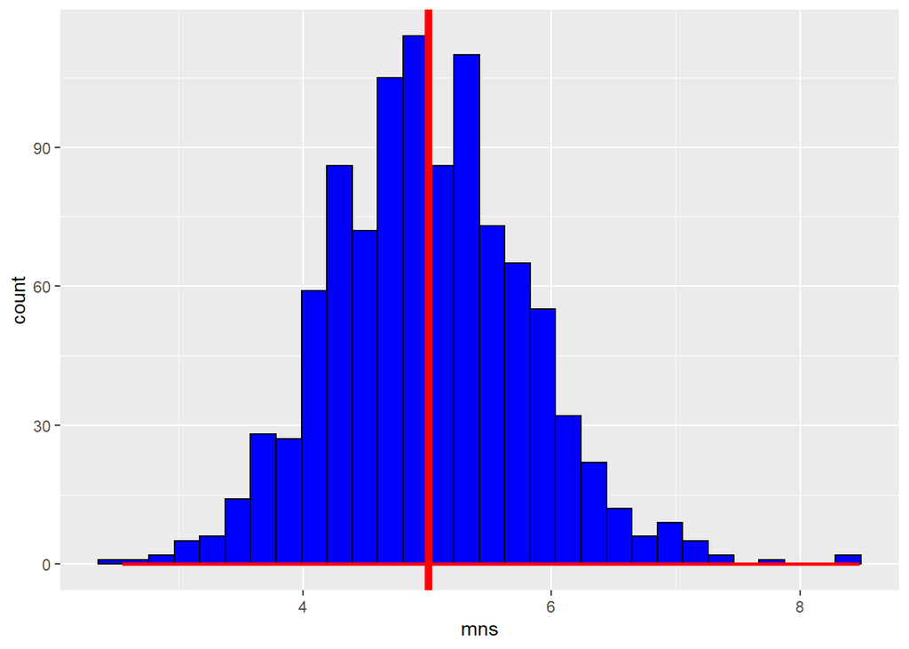

```r
#plot histogram with mean as red line
g<- ggplot(data.frame(data = mns), aes(x=mns)) + geom_histogram(color="black", fill= "blue") +geom_vline(aes(xintercept = mean(mns)),col='red',size=2)+
  stat_function(fun = dnorm, args = list(mean = 5 , sd = 5), colour = "red", size=1)
g
```

## Question 2: Sample Variance vs Theoretical Variance

The theoretical standard deviation for the exponential distribution is 1/lambda/sqrt(n). We can calculate this theoretical standard deviation and compare it to the standard deviation of the simulated data.

As you can see below, the observed and theoretical variance and standard deviation are nearly identical

```r
#theoretical standard deviation
1/lambda/sqrt(n_obs)
```

```
## [1] 0.7905694
```

```r
#observed standard deviation
sd(mns)
```

```
## [1] 0.7945364
```

```r
#theoretical variance
(1/lambda/sqrt(n_obs))^2
```

```
## [1] 0.625
```

```r
#observed variance
sd(mns)^2
```

```
## [1] 0.6312881
```

## Question 3: Distribution

The Central Limit Theorem holds that the means of a distribution are normally distributed. We will plot the means of the exponential functions. As you can see in the plot, the means are approximately normally distributed.

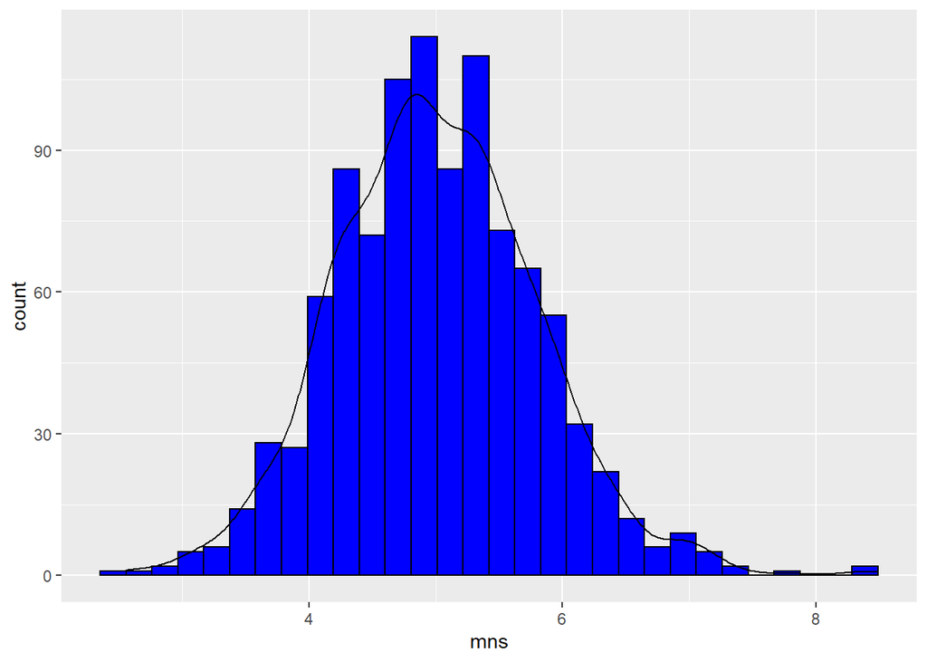

```r
#plot histogram with smoothed distribution and normal
g<- ggplot(data.frame(data = mns), aes(x=mns)) + geom_histogram(color="black", fill= "blue")+
 geom_density(aes(y=..count../5))
 # stat_function(fun = dnorm, args = list(mean = 5 , sd = 5), colour = "red", size=1)
g
```

## Part 2: Understanding Tooth Growth

## Overview

Now in the second portion of the project, we’re going to analyze the ToothGrowth data in the R datasets package.

Load the ToothGrowth data and perform some basic exploratory data analyses 1. Provide a basic summary of the data. 2. Use confidence intervals and/or hypothesis tests to compare tooth growth by supp and dose. (Only use the techniques from class, even if there’s other approaches worth considering) 3. State your conclusions and the assumptions needed for your conclusions.

ToothGrowth data set The response is the length of odontoblasts (cells responsible for tooth growth) in 60 guinea pigs. Each animal received one of three dose levels of vitamin C (0.5, 1, and 2 mg/day) by one of two delivery methods, orange juice or ascorbic acid (a form of vitamin C and coded as VC). Source: C. I. Bliss (1952). The Statistics of Bioassay. Academic Press

## Exploratory Analysis

```r
#load tooth growth data
data("ToothGrowth")

#look at summaries of the data
head(ToothGrowth)
```

```
##    len supp dose
## 1  4.2   VC  0.5
## 2 11.5   VC  0.5
## 3  7.3   VC  0.5
## 4  5.8   VC  0.5
## 5  6.4   VC  0.5
## 6 10.0   VC  0.5
```

```r
summary(ToothGrowth)
```

```
##       len        supp         dose
##  Min.   : 4.20   OJ:30   Min.   :0.500
##  1st Qu.:13.07   VC:30   1st Qu.:0.500
##  Median :19.25           Median :1.000
##  Mean   :18.81           Mean   :1.167
##  3rd Qu.:25.27           3rd Qu.:2.000
##  Max.   :33.90           Max.   :2.000
```

```r
str(ToothGrowth)
```

```
## 'data.frame':    60 obs. of  3 variables:
##  $ len : num  4.2 11.5 7.3 5.8 6.4 10 11.2 11.2 5.2 7 ...
##  $ supp: Factor w/ 2 levels "OJ","VC": 2 2 2 2 2 2 2 2 2 2 ...
##  $ dose: num  0.5 0.5 0.5 0.5 0.5 0.5 0.5 0.5 0.5 0.5 ...
```

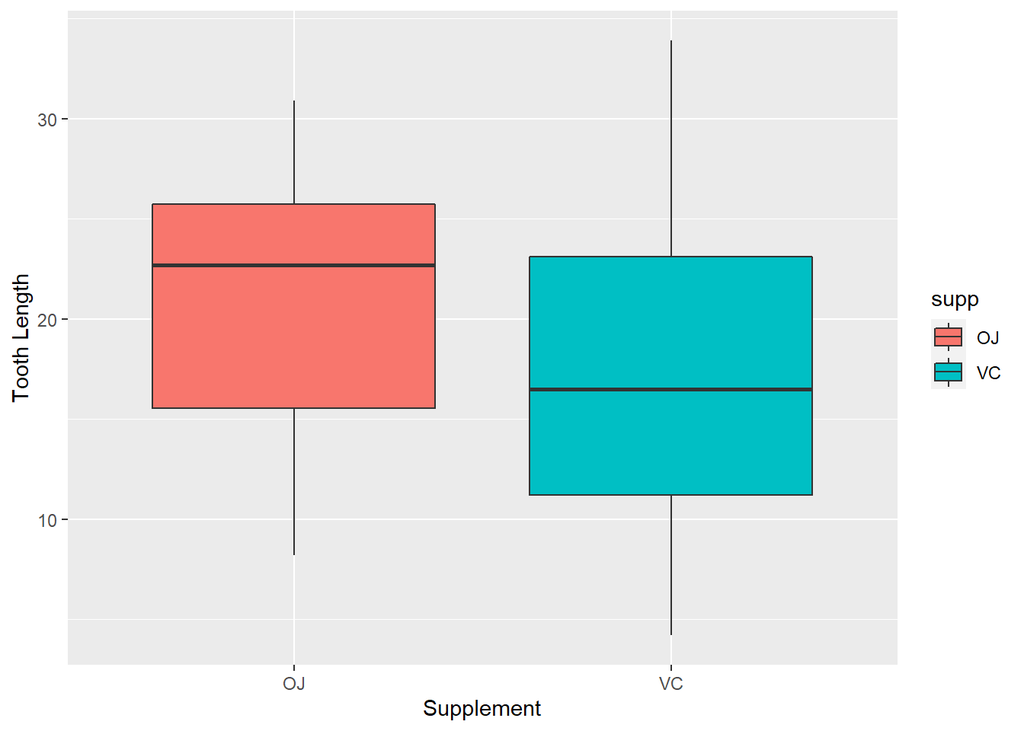

```r
#plot it
g1 <- ggplot(aes(x = supp, y = len), data = ToothGrowth) +
  geom_boxplot(aes(fill = supp))+labs(x="Supplement",y="Tooth Length")
g1
```

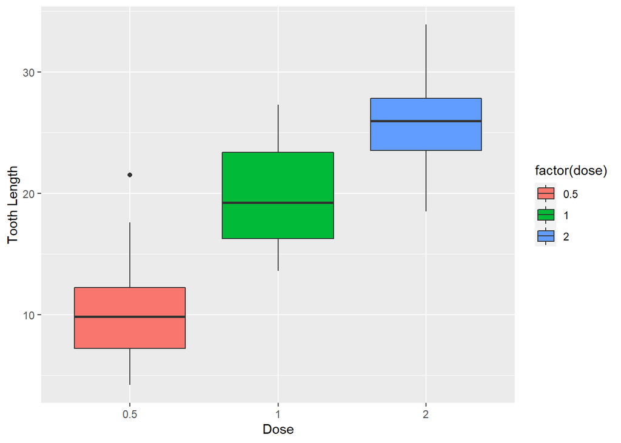

```r
g2<-ggplot(aes(x = factor(dose), y = len), data = ToothGrowth) +
    geom_boxplot(aes(fill = factor(dose)))+labs(x="Dose",y="Tooth Length")
g2
```

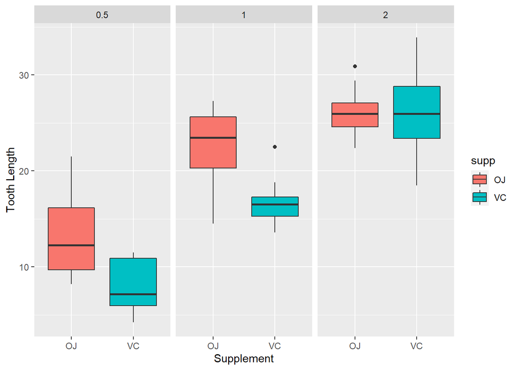

```r
g3<- ggplot(aes(x = supp, y = len), data = ToothGrowth) +
    geom_boxplot(aes(fill = supp)) + facet_wrap(~ dose)+labs(x="Supplement",y="Tooth Length")
g3
```

## Hypothesis Testing

```r
t.test(len ~ supp, data = ToothGrowth)
```

```
##
##  Welch Two Sample t-test
##
## data:  len by supp
## t = 1.9153, df = 55.309, p-value = 0.06063
## alternative hypothesis: true difference in means is not equal to 0
## 95 percent confidence interval:
##  -0.1710156  7.5710156
## sample estimates:
## mean in group OJ mean in group VC
##         20.66333         16.96333
```

```r
t.test(len ~ dose, data = subset(ToothGrowth, ToothGrowth$dose %in% c(0.5, 1.0)))
```

```
##
##  Welch Two Sample t-test
##
## data:  len by dose
## t = -6.4766, df = 37.986, p-value = 1.268e-07
## alternative hypothesis: true difference in means is not equal to 0
## 95 percent confidence interval:
##  -11.983781  -6.276219
## sample estimates:
## mean in group 0.5   mean in group 1
##            10.605            19.735
```

```r
t.test(len ~ dose, data = subset(ToothGrowth, ToothGrowth$dose %in% c(0.5, 2.0)))
```

```
##
##  Welch Two Sample t-test
##
## data:  len by dose
## t = -11.799, df = 36.883, p-value = 4.398e-14
## alternative hypothesis: true difference in means is not equal to 0
## 95 percent confidence interval:
##  -18.15617 -12.83383
## sample estimates:
## mean in group 0.5   mean in group 2
##            10.605            26.100
```

```r
t.test(len ~ dose, data = subset(ToothGrowth, ToothGrowth$dose %in% c(2.0, 1.0)))
```

```
##
##  Welch Two Sample t-test
##
## data:  len by dose
## t = -4.9005, df = 37.101, p-value = 1.906e-05
## alternative hypothesis: true difference in means is not equal to 0
## 95 percent confidence interval:
##  -8.996481 -3.733519
## sample estimates:
## mean in group 1 mean in group 2
##          19.735          26.100
```

Conclusions

Question 2; Does tooth growth vary depending on which dose level was used? H0: Supplement dose does not have an effect Tooth Length Ha: Supplement dose does have an effect on Tooth Length Result: The p-value for each pairing is less than 0.5, and the confidence intervals do not include 0, so we can reject the null hypothesis. There does seem to be a relationship between supplement dose and tooth growth.